# 2019 Capital Bikeshare Data Exploration

## by Mohamed Mounir Awadallah

## Preliminary Wrangling

This document explores a dataset containing information about rides made in a bike-sharing system covering the **Washington DC Metro Area**. The dataset used for this exploratory analysis consists of monthly individual trip data from January 2019 to December 2019 in CSV format, also available [here](https://s3.amazonaws.com/capitalbikeshare-data/index.html).

```python
# import all packages and set plots to be embedded inline
import numpy as np
import pandas as pd
import matplotlib.pyplot as plt
import seaborn as sb
from glob import glob
%matplotlib inline

import warnings
warnings.filterwarnings('ignore')
```

```python
# load in the datasets into pandas dataframes
data_files = sorted(glob('./data/*-capitalbikeshare-tripdata.csv'))
cabital = pd.concat((pd.read_csv(file).assign(filename = file)
                    for file in data_files), ignore_index = True)
```

```python
cabital.head()
```

|  | Duration | Start date | End date | Start station number | Start station | End station number | End station | Bike number | Member type | filename |
| --- | --- | --- | --- | --- | --- | --- | --- | --- | --- | --- |
| 0 | 230 | 2019-01-01 00:04:48 | 2019-01-01 00:08:39 | 31203 | 14th & Rhode Island Ave NW | 31200 | Massachusetts Ave & Dupont Circle NW | E00141 | Member | ./data\201901-capitalbikeshare-tripdata.csv |
| 1 | 1549 | 2019-01-01 00:06:37 | 2019-01-01 00:32:27 | 31321 | 15th St & Constitution Ave NW | 31114 | 18th St & Wyoming Ave NW | W24067 | Casual | ./data\201901-capitalbikeshare-tripdata.csv |
| 2 | 177 | 2019-01-01 00:08:46 | 2019-01-01 00:11:44 | 31104 | Adams Mill & Columbia Rd NW | 31323 | Woodley Park Metro / Calvert St & Connecticut ... | W22654 | Casual | ./data\201901-capitalbikeshare-tripdata.csv |
| 3 | 228 | 2019-01-01 00:08:47 | 2019-01-01 00:12:35 | 31281 | 8th & O St NW | 31280 | 11th & S St NW | W22336 | Member | ./data\201901-capitalbikeshare-tripdata.csv |
| 4 | 1300 | 2019-01-01 00:12:29 | 2019-01-01 00:34:10 | 31014 | Lynn & 19th St North | 31923 | Columbia Pike & S Taylor St | 70004 | Member | ./data\201901-capitalbikeshare-tripdata.csv |

```python
# Print a concise summary of the data
cabital.info()
```

```
<class 'pandas.core.frame.DataFrame'>
RangeIndex: 3398417 entries, 0 to 3398416
Data columns (total 10 columns):
 #   Column                Dtype
---  ------                -----
 0   Duration              int64
 1   Start date            object
 2   End date              object
 3   Start station number  int64
 4   Start station         object
 5   End station number    int64
 6   End station           object
 7   Bike number           object
 8   Member type           object
 9   filename              object
dtypes: int64(3), object(7)
memory usage: 259.3+ MB
```

```python
# Print a concise summary statistics
cabital.describe()
```

|  | Duration | Start station number | End station number |
| --- | --- | --- | --- |
| count | 3.398417e+06 | 3.398417e+06 | 3.398417e+06 |
| mean | 1.069698e+03 | 3.133744e+04 | 3.133799e+04 |
| std | 2.205485e+03 | 4.488496e+02 | 4.439744e+02 |
| min | 6.000000e+01 | 0.000000e+00 | 0.000000e+00 |
| 25% | 3.960000e+02 | 3.120400e+04 | 3.121200e+04 |
| 50% | 6.800000e+02 | 3.126500e+04 | 3.126400e+04 |
| 75% | 1.152000e+03 | 3.152400e+04 | 3.152400e+04 |
| max | 8.636500e+04 | 3.260900e+04 | 3.260900e+04 |

### What is the structure of your dataset?

The data includes:

- `Duration` – Duration of trip
- `Start Date` – Includes start date and time
- `End Date` – Includes end date and time
- `Start Station` – Includes starting station name and number
- `End Station` – Includes ending station name and number
- `Bike Number` – Includes ID number of bike used for the trip
- `Member Type` – Indicates whether user was a "registered" member (Annual Member, 30-Day Member or Day Key Member) or a "casual" rider (Single Trip, 24-Hour Pass, 3-Day Pass or 5-Day Pass)

### What are the main features of interest in your dataset?

- What is the average trip duration?
- When are most trips taken?
- What are the most common starting and ending stations?
- Does the above depend on if a user is a subscriber or customer?

### What features in the dataset do you think will help support your investigation into your feature(s) of interest?

- `Duration`
- `Start Date`
- `Start Station`
- `End Station`
- `Member Type`

## Univariate Exploration

```python
# changing the duration unit to minutes
cabital['Duration'] = (cabital['Duration'] / 60).round(2)
```

```python
# converting start date and end date data types into datetime
cabital['Start date'] = pd.to_datetime(cabital['Start date'])
cabital['End date'] = pd.to_datetime(cabital['End date'])
```

```python
# extracting Day, Week and Month from Start date
cabital['Day'] = cabital['Start date'].dt.day_name()
cabital['Month'] = cabital['Start date'].dt.month_name()

cabital.sample(5)
```

|  | Duration | Start date | End date | Start station number | Start station | End station number | End station | Bike number | Member type | filename | Day | Month |
| --- | --- | --- | --- | --- | --- | --- | --- | --- | --- | --- | --- | --- |
| 411701 | 25.15 | 2019-03-15 18:58:41 | 2019-03-15 19:23:51 | 31228 | 8th & H St NW | 31401 | 14th St & Spring Rd NW | W00239 | Member | ./data\201903-capitalbikeshare-tripdata.csv | Friday | March |
| 3271959 | 11.58 | 2019-12-06 11:28:38 | 2019-12-06 11:40:13 | 31201 | 15th & P St NW | 31221 | 18th & M St NW | W24102 | Member | ./data\201912-capitalbikeshare-tripdata.csv | Friday | December |
| 1397724 | 1.80 | 2019-06-13 20:23:32 | 2019-06-13 20:25:21 | 31209 | 1st & N St SE | 31208 | M St & New Jersey Ave SE | W22120 | Member | ./data\201906-capitalbikeshare-tripdata.csv | Thursday | June |
| 618342 | 20.42 | 2019-04-06 13:56:30 | 2019-04-06 14:16:56 | 31229 | New Hampshire Ave & T St NW | 31312 | Wisconsin Ave & O St NW | W22652 | Member | ./data\201904-capitalbikeshare-tripdata.csv | Saturday | April |
| 2953820 | 7.90 | 2019-10-26 07:22:34 | 2019-10-26 07:30:28 | 31269 | 3rd St & Pennsylvania Ave SE | 31623 | Columbus Circle / Union Station | W23414 | Member | ./data\201910-capitalbikeshare-tripdata.csv | Saturday | October |

```python
# extracting Day type from day
weekdays = ['Monday', 'Tuesday', 'Wednesday', 'Thursday', 'Friday']
weekend = ['Saturday', 'Sunday']

weekdays_index = cabital.loc[cabital['Day'].isin(weekdays)].index
weekend_index = cabital.loc[cabital['Day'].isin(weekend)].index

cabital['Day type'] = ''
cabital['Day type'][weekdays_index] = 'Weekday'
cabital['Day type'][weekend_index] = 'Weekend'
cabital['Day type'].value_counts()
```

```
Weekday    2502410
Weekend     896007
Name: Day type, dtype: int64
```

```python
# extracting Season fron Start date
spring = ['March', 'April', 'May']
summer = ['June', 'July', 'August']
fall = ['September', 'October', 'November']
winter = ['December', 'January', 'February']

spring_index = cabital.loc[cabital['Month'].isin(spring)].index
summer_index = cabital.loc[cabital['Month'].isin(summer)].index
fall_index = cabital.loc[cabital['Month'].isin(fall)].index
winter_index = cabital.loc[cabital['Month'].isin(winter)].index

cabital['Season'] = ''
cabital['Season'][spring_index] = 'Spring'
cabital['Season'][summer_index] = 'Summer'
cabital['Season'][fall_index] = 'Fall'
cabital['Season'][winter_index] = 'Winter'
cabital['Season'].value_counts()
```

```
Summer    1066833
Spring     939507
Fall       921289
Winter     470788
Name: Season, dtype: int64
```

```python
cabital.sample(5)
```

|  | Duration | Start date | End date | Start station number | Start station | End station number | End station | Bike number | Member type | filename | Day | Month | Day type | Season |
| --- | --- | --- | --- | --- | --- | --- | --- | --- | --- | --- | --- | --- | --- | --- |
| 351334 | 9.27 | 2019-03-09 09:33:58 | 2019-03-09 09:43:15 | 31201 | 15th & P St NW | 31503 | Florida Ave & R St NW | W22279 | Member | ./data\201903-capitalbikeshare-tripdata.csv | Saturday | March | Weekend | Spring |
| 2535933 | 12.43 | 2019-09-19 16:39:50 | 2019-09-19 16:52:16 | 31515 | Fort Totten Metro | 31405 | Georgia Ave & Emerson St NW | W20709 | Member | ./data\201909-capitalbikeshare-tripdata.csv | Thursday | September | Weekday | Fall |
| 1702669 | 25.75 | 2019-07-10 11:47:16 | 2019-07-10 12:13:01 | 31288 | 4th St & Madison Dr NW | 31289 | Henry Bacon Dr & Lincoln Memorial Circle NW | W22027 | Casual | ./data\201907-capitalbikeshare-tripdata.csv | Wednesday | July | Weekday | Summer |
| 2152416 | 21.55 | 2019-08-17 13:04:51 | 2019-08-17 13:26:25 | 31523 | Lincoln Rd & Seaton Pl NE/Harry Thomas Rec Center | 31230 | Metro Center / 12th & G St NW | W22778 | Member | ./data\201908-capitalbikeshare-tripdata.csv | Saturday | August | Weekend | Summer |
| 2959930 | 20.92 | 2019-10-26 15:53:19 | 2019-10-26 16:14:15 | 31029 | N Veitch St & 20th St N | 31226 | 34th St & Wisconsin Ave NW | W22631 | Member | ./data\201910-capitalbikeshare-tripdata.csv | Saturday | October | Weekend | Fall |

```python
# setting the base color for plots
base_color = sb.color_palette()[0]
```

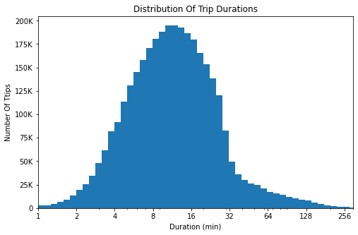

```python
# distribution of trip durations
log_binsize = 0.05
bins = 10 ** np.arange(0, np.log10(cabital['Duration'].max())+log_binsize, log_binsize)
x_ticks = [1,2,4,8,16,32,64,128,256]
plt.figure(figsize=[8, 5])
plt.hist(data = cabital,x='Duration' ,bins = bins)
plt.xlim([1,300])
plt.xscale('log')
plt.xticks(x_ticks,x_ticks)
plt.yticks([0,25000,50000,75000,100000,125000,150000,175000,200000],
          ['0','25K','50K','75K','100K','125K','150K','175K','200K'])
plt.title('Distribution Of Trip Durations')
plt.xlabel('Duration (min)')
plt.ylabel('Number Of Ttips');
```

- Most of the **duration** of the trips is **between 4 and 32 minutes**.

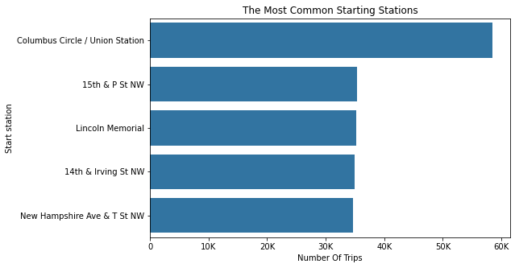

```python
# the most common starting stations
start_5 = cabital['Start station'].value_counts()[:5]
plt.figure(figsize=[8, 5])
sb.countplot(data=cabital,y='Start station', order = start_5.index, color=base_color)
plt.title('The Most Common Starting Stations')
plt.xlabel('Number Of Trips')
plt.xticks([0,10000,20000,30000,40000,50000,60000],
          ['0','10K','20K','30K','40K','50K','60K']);
```

- The most common starting station is **Columbus Circle / Union Station**.

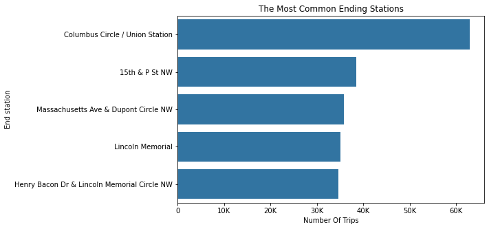

```python
# the most common endting stations
end_10 = cabital['End station'].value_counts()[:5]
plt.figure(figsize=[8, 5])
sb.countplot(data=cabital, y='End station', order = end_10.index, color=base_color)
plt.title('The Most Common Ending Stations')
plt.xlabel('Number Of Trips')
plt.xticks([0,10000,20000,30000,40000,50000,60000],
          ['0','10K','20K','30K','40K','50K','60K']);
```

- The most common ending station is **Columbus Circle / Union Station**.

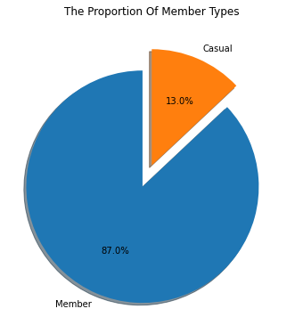

```python
# the proportion of member types
Member = cabital['Member type'].value_counts()
explode = [0.2, 0]
plt.figure(figsize=[6, 6])
plt.pie(Member, labels=Member.index,startangle=90,explode = explode,
        shadow = True, autopct='%1.1f%%');
plt.title('The Proportion Of Member Types');
```

- The percentage of the trips made by **registered members = 87%**
- The percentage of the trips made by **Casual Members = 13%**

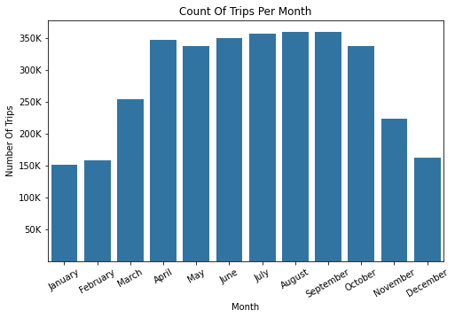

```python
# count of trips per month
plt.figure(figsize=[8, 5])
sb.countplot(data=cabital, x='Month', color=base_color)
plt.ylabel('Number Of Trips')
plt.title('Count Of Trips Per Month')
plt.xticks(rotation=30)
plt.yticks([50000,100000,150000,200000,250000,300000,350000],
          ['50K','100K','150K','200K','250K','300K','350K']);
```

- The number of trips **increases between the months of April to October**, while it **decreases between the months of December to February**.

> It seems the number of trips decrease in the winter months so let's investigate the count of trips per season.

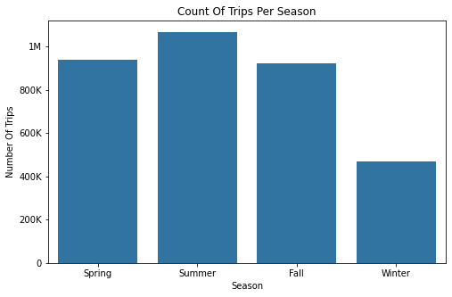

```python
# count of trips per season
seasons = ['Spring','Summer','Fall','Winter']
plt.figure(figsize=[8, 5])
sb.countplot(data=cabital, x='Season', color=base_color, order=seasons)
plt.ylabel('Number Of Trips')
plt.title('Count Of Trips Per Season')
plt.yticks([0,200000,400000,600000,800000,1000000],
          ['0','200K','400K','600K','800K','1M']);
```

- The number of trips **increases in the Summer** months, while it **decreases in the Winter** months.

```python
# calculating the average daily trips per season
season_counts = cabital.groupby(['Season']).count()['Duration']
season_daily = pd.DataFrame(season_counts / 91).reset_index()
season_daily.rename(columns = {'Duration':'Daily trips'}, inplace = True)
season_daily
```

|  | Season | Daily trips |
| --- | --- | --- |
| 0 | Fall | 10124.054945 |
| 1 | Spring | 10324.252747 |
| 2 | Summer | 11723.439560 |
| 3 | Winter | 5173.494505 |

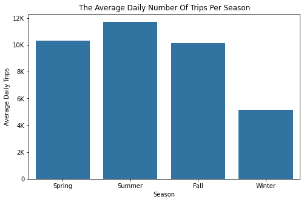

```python
# the average daily trips per season
plt.figure(figsize=[8, 5])
sb.barplot(data=season_daily, x='Season', y='Daily trips', order=seasons, color=base_color)
plt.title('The Average Daily Number Of Trips Per Season')
plt.xlabel('Season')
plt.ylabel('Average Daily Trips')
plt.xticks(rotation = 0)
plt.yticks([0,2000,4000,6000,8000,10000,12000],
          ['0','2K','4K','6K','8K','10K','12K']);
```

- The Average Daily trips **in the Summer is about 11.5K**, while **in the Winter ia about 5K**.

  > Let's investigate the count of trips per days of the week

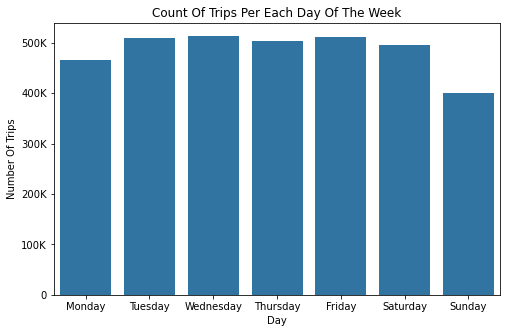

```python
# count of trips per days of the week
days = ['Monday','Tuesday','Wednesday','Thursday',
        'Friday','Saturday','Sunday']
plt.figure(figsize=[8, 5])
sb.countplot(data=cabital, x='Day', color=base_color, order=days)
plt.title('Count Of Trips Per Each Day Of The Week')
plt.ylabel('Number Of Trips')
plt.yticks([0,100000,200000,300000,400000,500000],
          ['0','100K','200K','300K','400K','500K']);
```

- The number of trips **decreases on Sundays**.

  > Let's investigate the average daily trips on each day of the week

```python
# calculating the average daily trips on each day of the week
start_date =  cabital['Start date'].min().date()
end_date =  cabital['Start date'].max().date()

av_daily_trips = pd.DataFrame(cabital.Day.value_counts().rename_axis('Day').reset_index(name='Trips_count'))
av_daily_trips['Average_trips'] = (av_daily_trips.Trips_count / np.busday_count(start_date,end_date,'1000000')).astype(int)
av_daily_trips
```

|  | Day | Trips_count | Average_trips |
| --- | --- | --- | --- |
| 0 | Wednesday | 513457 | 9874 |
| 1 | Friday | 510515 | 9817 |
| 2 | Tuesday | 510178 | 9811 |
| 3 | Thursday | 503090 | 9674 |
| 4 | Saturday | 496048 | 9539 |
| 5 | Monday | 465170 | 8945 |
| 6 | Sunday | 399959 | 7691 |

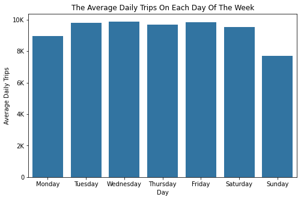

```python
# the average daily trips on each day of the week
plt.figure(figsize=[8, 5])
sb.barplot(data=av_daily_trips, x='Day', y='Average_trips', order=days, color=base_color)
plt.title('The Average Daily Trips On Each Day Of The Week')
plt.xlabel('Day')
plt.ylabel('Average Daily Trips')
plt.xticks(rotation = 0)
plt.yticks([0,2000,4000,6000,8000,10000],
          ['0','2K','4K','6K','8K','10K']);
```

- **Sunday has the lowest** average daily trips with lower than 8K trips.

  > Let's investigate the average daily trips on weekdays and weekends

```python
# calculating the number of weekdays and weekends in the whole period of time
no_of_weekdays = np.busday_count(start_date,end_date,'1111100')
no_of_weekends = np.busday_count(start_date,end_date,'0000011')
```

```python
# calculating the average number of trips on both day types
week_counts = cabital.groupby(['Day type']).count()['Duration']
week_proportion = pd.DataFrame(week_counts / [no_of_weekdays ,no_of_weekends]).reset_index()
week_proportion.rename(columns = {'Duration':'Daily trips'}, inplace = True)
```

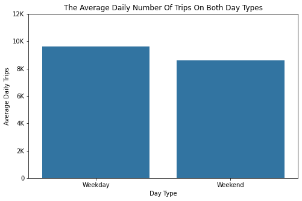

```python
# the average daily trips on both day types
plt.figure(figsize=[8, 5])
sb.barplot(data=week_proportion, x='Day type', y='Daily trips', color=base_color)
plt.title('The Average Daily Number Of Trips On Both Day Types')
plt.xlabel('Day Type')
plt.ylabel('Average Daily Trips')
plt.xticks(rotation = 0)
plt.yticks([0,2000,4000,6000,8000,10000,12000],
          ['0','2K','4K','6K','8K','10K','12K']);
```

- The average **daily trips on weekends are lower than daily trips on weekdays**.

### Discuss the distribution(s) of your variable(s) of interest. Were there any unusual points? Did you need to perform any transformations?

> - Most of the duration of the trips is between 4 and 32 minutes.
> - The most common starting and ending station is Columbus Circle / Union Station.
> - The percentage of the trips made by registered members = 87%, while Casual Members = 13%
> - The average daily trips increases in the Summer months, while it decreases in the Winter months.
> - The average daily trips decrease on the weekend days, especially on Sundays.

### Of the features you investigated, were there any unusual distributions? Did you perform any operations on the data to tidy, adjust, or change the form of the data? If so, why did you do this?

> - Converting `Duration` unit from seconds to miunits.
> - Converting `Start date` and `End date` data type into datetime.
> - Extracting `Day` and `Month` from `Start dete`.
> - Extracting `Day type` (weekday / weekend) from `Day`.
> - Extracting `Season` from `Month`.

## Bivariate Exploration

> In this section, investigate relationships between pairs of variables in your data. Make sure the variables that you cover here have been introduced in some fashion in the previous section (univariate exploration).

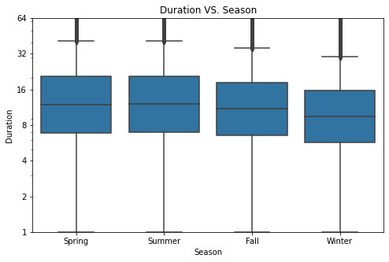

```python
# bivariate plot of duration vs. season
plt.figure(figsize=[8, 5])
box_plot = sb.boxplot(data=cabital, x='Season', y='Duration', color=base_color, order=seasons)
y_ticks = [1,2,4,8,16,32,64]
plt.ylim([1,64])
plt.yscale('log')
plt.yticks(y_ticks,y_ticks)
plt.title('Duration VS. Season');
```

- The average **trip durations are shorter in winter**.

  > Let's investigate the trip duration vs. days of the week

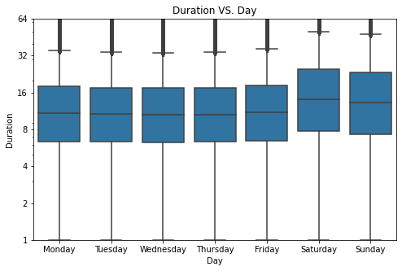

```python
# bivariate plot of duration vs. day
plt.figure(figsize=[8, 5])
box_plot = sb.boxplot(data=cabital, x='Day', y='Duration',order=days, color=base_color)
y_ticks = [1,2,4,8,16,32,64]
plt.ylim([1,64])
plt.yscale('log')
plt.yticks(y_ticks,y_ticks)
plt.title('Duration VS. Day');
```

- The average **trip durations are longer on Saturday and Sunday**.

  > Let's investigate the trip duration vs. day type

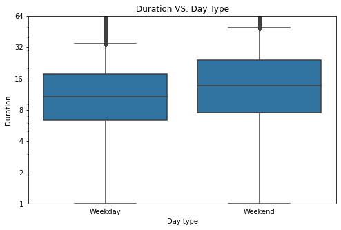

```python
# bivariate plot of duration vs. day type
plt.figure(figsize=[8, 5])
box_plot = sb.boxplot(data=cabital, x='Day type', y='Duration', color=base_color)
y_ticks = [1,2,4,8,16,32,64]
plt.ylim([1,64])
plt.yscale('log')
plt.yticks(y_ticks,y_ticks)
plt.title('Duration VS. Day Type');
```

- The average **trip durations are longer on weekends than weekdays**.

  > Let's investigate the trip duration vs. member type

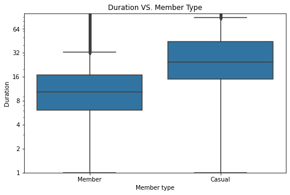

```python
# bivariate plot of duration vs. member type
plt.figure(figsize=[8, 5])
box_plot = sb.boxplot(data=cabital, x='Member type', y='Duration', color=base_color)
y_ticks = [1,2,4,8,16,32,64]
plt.ylim([1,100])
plt.yscale('log')
plt.yticks(y_ticks,y_ticks)
plt.title('Duration VS. Member Type');
```

- The average **trip durations are longer for casual members**.

  > Let's investigate the season vs. member type

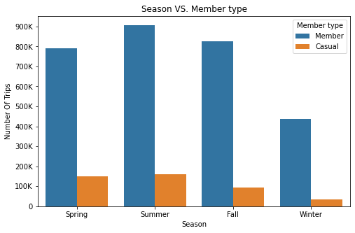

```python
# bivariate plot of season vs. member type
plt.figure(figsize=[8, 5])
sb.countplot(data=cabital, x='Season', hue='Member type', order=seasons)
plt.title('Season VS. Member type')
plt.ylabel('Number Of Trips')
plt.yticks([0,100000,200000,300000,400000,500000,600000,700000,800000,900000],
          ['0','100K','200K','300K','400K','500K','600K','700K','800K','900K']);
```

- **Summer has the largest number of trips for both member types**.

  > Let's investigate the day type vs. member type

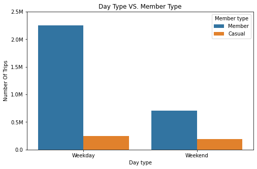

```python
# bivariate plot of day type vs. member type
plt.figure(figsize=[8, 5])
sb.countplot(data=cabital, x='Day type', hue='Member type')
plt.ylabel('Number Of Trips')
plt.title('Day Type VS. Member Type')
plt.yticks([0,0.5e6,1e6,1.5e6,2e6,2.5e6],
          ['0.0','0.5M','1.0M','1.5M','2.0M','2.5M']);
```

- **Weekdays have a larger number of trips than weekends for both member types**.

### Talk about some of the relationships you observed in this part of the investigation. How did the feature(s) of interest vary with other features in the dataset?

> - The average trip durations are shorter in winter.
> - The average trip durations are longer on weekends than weekdays.
> - The average trip durations are longer for casual members than members.

### Did you observe any interesting relationships between the other features (not the main feature(s) of interest)?

> - Summer has the largest number of trips for both member types.
> - Weekdays have a larger number of trips than weekends for both member types.

## Multivariate Exploration

> Create plots of three or more variables to investigate your data even further. Make sure that your investigations are justified, and follow from your work in the previous sections.

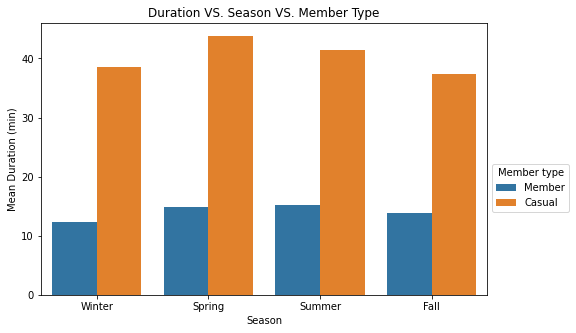

```python
# multivariate plot of duration vs season vs member type
plt.figure(figsize=[8, 5])
sb.barplot(data=cabital, x='Season', y='Duration', hue='Member type', ci=None)
plt.title('Duration VS. Season VS. Member Type')
plt.ylabel('Mean Duration (min)')
plt.legend(bbox_to_anchor = (1,0.5),title='Member type');
```

- The mean duration of trips for **Spring and Summer is longer than Fall and Winter for each of the member types**.

  > Let's investigate duration vs season vs day type

```python
# define day_type_color
day_type_color = [sb.color_palette()[2],sb.color_palette()[3]]
```

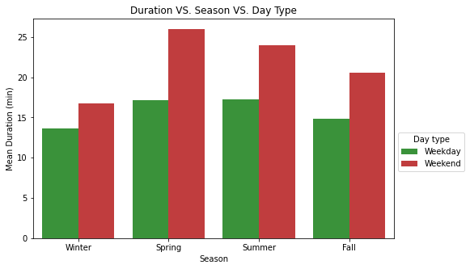

```python
# multivariate plot of duration vs season vs day type
plt.figure(figsize=[8, 5])
sb.barplot(data=cabital, x='Season', y='Duration', hue='Day type', ci=None, palette=day_type_color)
plt.title('Duration VS. Season VS. Day Type')
plt.ylabel('Mean Duration (min)')
plt.legend(bbox_to_anchor = (1,0.5),title='Day type');
```

- The mean duration of trips for **Spring and Summer is longer than Fall and Winter for each of the day types**.

  > Let's investigate duration vs member type vs day type

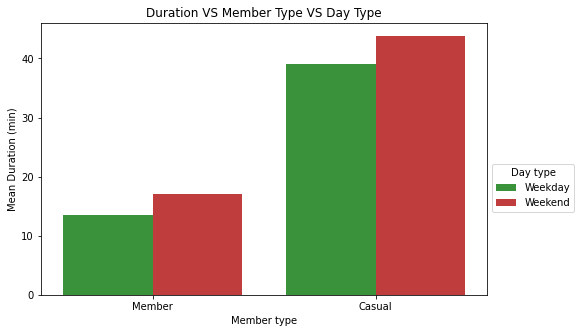

```python
# multivariate plot of duration vs member type vs day type
plt.figure(figsize=[8, 5])
sb.barplot(data=cabital, x='Member type', y='Duration', hue='Day type', ci=None, palette=day_type_color)
plt.title('Duration VS Member Type VS Day Type')
plt.ylabel('Mean Duration (min)')
plt.legend(bbox_to_anchor = (1,0.5),title='Day type');
```

- The mean duration of trips for **casual members is longer than members for each of the day types**.
- The mean duration of trips on **the weekends is longer than weekdays for each of the member types**.

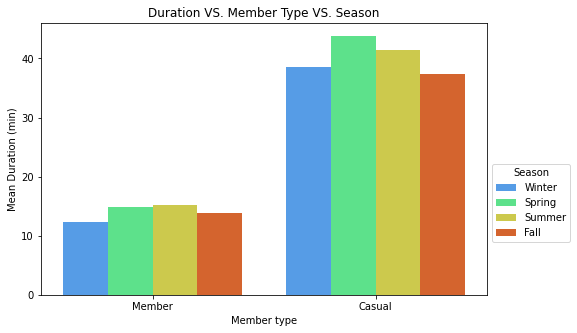

```python
# multivariate plot of duration vs member type vs season
plt.figure(figsize=[8, 5])
sb.barplot(data=cabital, x='Member type', y='Duration', hue='Season', ci=None, palette='turbo')
plt.title('Duration VS. Member Type VS. Season')
plt.ylabel('Mean Duration (min)')
plt.legend(bbox_to_anchor = (1,0.5),title='Season');
```

- **Casual members have a longer mean trip duration than members**.
- **Winter has the shortest mean trip duration for members**.
- **Fall has the shortest mean trip duration for casual members**.

### Talk about some of the relationships you observed in this part of the investigation. Were there features that strengthened each other in terms of looking at your feature(s) of interest?

> - The mean duration of trips for Spring and Summer is longer than Fall and Winter for each of the member types and for each of the day types.
> - The mean duration of trips for casual members is longer than members for each of the day types.
> - The mean duration of trips on the weekends is longer than weekdays for each of the member types.
> - Casual members have a longer mean trip duration than members.
> - Winter has the shortest mean trip duration for members.
> - Fall has the shortest mean trip duration for casual members.

### Were there any interesting or surprising interactions between features?

> - The average trip durations are longer for casual members than members.
> - The average trip durations are longer on weekends than weekdays.